# STAT 479 Project 3 - NFL Big Data Bowl

# Calculate Air-Time Separation Score (ATS-Score)

The ATS-Score quantifies a receiver’s ability to create and maintain separation from the nearest defender while the ball is in the air. It is the time-averaged minimum separation between the targeted receiver and the closest defensive player during the pass flight.

### Prepare Tracking Data for Separation Calculation

```r
# 1. Create a unique play/player ID to help with grouping and joining
df_output_all = df_output_all %>%
  mutate(play_player_id = paste(game_id, play_id, nfl_id, sep = "_"))

# 2. Extract key player information and roles from the input data.
# We only need one row per player per play to get their role so using the last frame of the input is sufficient to define player roles/sides.
df_player_roles = df_input_all %>% # players involved in play and their roles
  distinct(game_id, play_id, nfl_id, player_side, player_role) %>%
  # Filter only for the players relevant to the score: Targeted Receiver and Defensive Coverage
  filter(player_role %in% c("Targeted Receiver", "Defensive Coverage"))

# 3. Join player roles and side onto the output (post-pass) tracking data.
df_tracking_prepared = df_output_all %>%
  left_join(df_player_roles, by = c("game_id", "play_id", "nfl_id")) %>%
  # Filter out rows where the join failed (e.g., non-receiver/defender players)
  filter(!is.na(player_role))

# 4. Separate the receiver's tracking data from the defenders' tracking data.
df_receiver_tracking = df_tracking_prepared %>%
  filter(player_role == "Targeted Receiver") %>%
  dplyr::select(game_id, play_id, frame_id, receiver_x = x, receiver_y = y)

df_defender_tracking = df_tracking_prepared %>%
  filter(player_role == "Defensive Coverage") %>%
  # Rename columns for clarity in the subsequent separation calculation
  rename(defender_x = x, defender_y = y) %>%
  dplyr::select(game_id, play_id, nfl_id, frame_id, defender_x, defender_y)

# Print dimensions of the key intermediate dataframes
cat("Dimensions of df_tracking_prepared:", dim(df_tracking_prepared), "\n")
```

```
## Dimensions of df_tracking_prepared: 562936 9
```

```r
cat("Dimensions of df_receiver_tracking:", dim(df_receiver_tracking), "\n")
```

```
## Dimensions of df_receiver_tracking: 160360 5
```

```r
cat("Dimensions of df_defender_tracking:", dim(df_defender_tracking), "\n")
```

```
## Dimensions of df_defender_tracking: 402576 6
```

```r
# Display head of the receiver tracking data
df_receiver_tracking %>% head() %>% print()
```

```
## # A tibble: 6 × 5
##      game_id play_id frame_id receiver_x receiver_y
##        <dbl>   <dbl>    <dbl>      <dbl>      <dbl>
## 1 2023090700     101        1       53.2       14.0
## 2 2023090700     101        2       54.0       13.8
## 3 2023090700     101        3       54.7       13.5
## 4 2023090700     101        4       55.4       13.3
## 5 2023090700     101        5       56.1       13.0
## 6 2023090700     101        6       56.7       12.6
```

### Frame-by-Frame Minimum Separation

Join the receiver and defender tracking data, calculates the Euclidean distance (separation) for every receiver-defender pair in every frame, and identifies the minimum separation distance for each frame of every play. The forumula for the distance separation is
$$\text{Separation Distance} =
\sqrt{(\text{Receiver}_x - \text{Defender}_x)^2 + (\text{Receiver}_y -
\text{Defender}_y)^2}$$

```r
# 1. Join Receiver and Defender Tracking Data
# This is a Cartesian join based on Game, Play, and Frame, pairing the single receiver position with all defender positions for that moment in time.
df_all_separation = df_receiver_tracking %>%
  left_join(df_defender_tracking, by = c("game_id", "play_id", "frame_id")) %>%
  # Filter out plays where no defender was present in the output data
  filter(!is.na(nfl_id))

# 2. Calculate Euclidean Distance (Separation)
df_min_separation = df_all_separation %>%
  mutate(
    separation_dist = sqrt((receiver_x - defender_x)^2 + (receiver_y - defender_y)^2)
  ) %>%
  # 3. Find the Minimum Separation for Each Frame
  # Group by the unique frame ID (Game, Play, Frame)
  group_by(game_id, play_id, frame_id) %>%
  summarise(
    # Find the minimum separation among all defenders for that frame
    min_separation = min(separation_dist),
    # Keep the NFL ID of the closest defender for later analysis
    closest_defender_id = nfl_id[which.min(separation_dist)][1],
    .groups = 'drop'
  )

# Display the first few rows of the minimum separation data
cat("Dimensions of df_min_separation:", dim(df_min_separation), "\n")
```

```
## Dimensions of df_min_separation: 151698 5
```

```r
df_min_separation %>% head() %>% print()
```

```
## # A tibble: 6 × 5
##      game_id play_id frame_id min_separation closest_defender_id
##        <dbl>   <dbl>    <dbl>          <dbl>               <dbl>
## 1 2023090700     101        1           4.47               46137
## 2 2023090700     101        2           4.09               46137
## 3 2023090700     101        3           3.75               46137
## 4 2023090700     101        4           3.44               46137
## 5 2023090700     101        5           3.18               46137
## 6 2023090700     101        6           2.99               46137
```

### Calculate the Air-Time Separation Score (ATS-Score) and Merge with Play Data

```r
# 1. Calculate the ATS-Score (Average Minimum Separation) per Play
#  ATS-Score = time-averaged minimum separation distance during the pass flight.
df_ats_score = df_min_separation %>%
  group_by(game_id, play_id) %>%
  summarise(
    # ATS-Score is the time-averaged minimum separation
    ats_score = mean(min_separation),
    # Calculate the minimum separation achieved during the entire pass flight
    min_separation_achieved = min(min_separation),
    .groups = 'drop'
  ) %>%
  left_join(df_min_separation %>% select(c(game_id, play_id, min_separation, closest_defender_id)) %>% rename(min_separation_achieved = min_separation), by=c('game_id', 'play_id', 'min_separation_achieved'))

# 2. Merge the ATS-Score with the Supplementary Play Data
# Use an inner_join to keep only the plays for which we successfully calculated an ATS-Score.
df_ats_analysis = df_plays %>%
  inner_join(df_ats_score, by = c("game_id", "play_id")) %>%
  # Filter for plays that resulted in a pass (C, I, IN, S, R) and were not nullified by penalty
  filter(pass_result %in% c("C", "I", "IN", "S", "R"),
         play_nullified_by_penalty == "N")

# 3. Clean and categorize the pass results for simpler analysis:
df_ats_analysis = df_ats_analysis %>%
  mutate(
    outcome_category = case_when(
      pass_result == "C" ~ "Completed",
      pass_result == "I" ~ "Incomplete",
      pass_result == "IN" ~ "Interception",
      # Group Sacks and Scrambles into "Other" since tracking data might be partial for these outcomes
      TRUE ~ "Other"
    ),
    # Simple binary outcome for completion rate analysis
    is_completed = ifelse(pass_result == "C", 1, 0)
  )

# Display dimensions and summary statistics for the final dataset
cat("Dimensions of df_ats_analysis:", dim(df_ats_analysis), "\n")
```

```
## Dimensions of df_ats_analysis: 12975 46
```

```r
df_ats_analysis %>%
  dplyr::select(game_id, play_id, pass_result, outcome_category, ats_score, min_separation_achieved) %>%
  head() %>%
  print()
```

```
## # A tibble: 6 × 6
##    game_id play_id pass_result outcome_category ats_score min_separation_achie…¹
##      <dbl>   <dbl> <chr>       <chr>                <dbl>                  <dbl>
## 1   2.02e9    3461 C           Completed             3.31                  3.10
## 2   2.02e9     461 C           Completed             4.84                  3.61
## 3   2.02e9    1940 I           Incomplete            5.37                  3.66
## 4   2.02e9    1711 C           Completed             6.71                  4.03
## 5   2.02e9    1588 I           Incomplete            1.17                  0.899
## 6   2.02e9     101 I           Incomplete            2.60                  1.84
## # ℹ abbreviated name: ¹min_separation_achieved
```

```r
cat("\nSummary of ATS-Score (yards):\n")
```

```
##
## Summary of ATS-Score (yards):
```

```r
summary(df_ats_analysis$ats_score) %>% print()
```

```
##    Min. 1st Qu.  Median    Mean 3rd Qu.    Max.
##  0.2242  1.7295  3.0667  3.5946  4.8403 45.1192
```

### Analysis 1: ATS-Score by Play Outcome

Validate the ATS-Score by comparing its distribution across different pass outcomes. The hypthesis is that Completed passes will have a significantly higher average ATS-Score (more separation) than Incomplete passes or Interceptions.

```r
# 1. Calculate Descriptive Statistics: Mean ATS-Score by Outcome
ats_summary = df_ats_analysis %>%
  # Filter only for the primary pass outcomes
  filter(outcome_category %in% c("Completed", "Incomplete", "Interception")) %>%
  group_by(outcome_category) %>%
  summarise(
    N = n(),
    Mean_ATS_Score = mean(ats_score),
    Median_ATS_Score = median(ats_score),
    .groups = 'drop'
  )

ats_summary %>% print()
```

```
## # A tibble: 3 × 4
##   outcome_category     N Mean_ATS_Score Median_ATS_Score
##   <chr>            <int>          <dbl>            <dbl>
## 1 Completed         8688           4.14             3.71
## 2 Incomplete        3952           2.49             1.77
## 3 Interception       335           2.52             2.17
```

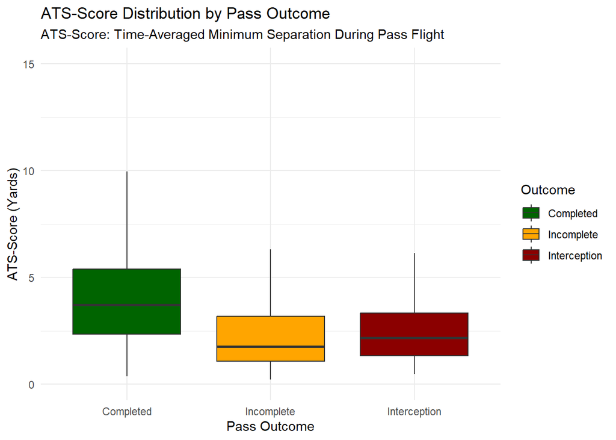

```r
# 2. Visualization: Box Plot of ATS-Score vs. Outcome
plot_ats_outcome = df_ats_analysis %>%
  filter(outcome_category %in% c("Completed", "Incomplete", "Interception")) %>%
  ggplot(aes(x = outcome_category, y = ats_score, fill = outcome_category)) +
  geom_boxplot(outlier.shape = NA) + # Hide extreme outliers to focus on the bulk of the data
  scale_fill_manual(values = c("Completed" = "darkgreen", "Incomplete" = "orange", "Interception" = "darkred")) +
  labs(
    title = "ATS-Score Distribution by Pass Outcome",
    subtitle = "ATS-Score: Time-Averaged Minimum Separation During Pass Flight",
    x = "Pass Outcome",
    y = "ATS-Score (Yards)",
    fill = "Outcome"
  ) +
  theme_minimal() +
  # zoom for better readability
  coord_cartesian(ylim = c(0, 15))

print(plot_ats_outcome)
```

```r
#ggsave("ats_score_by_outcome_boxplot.png", plot_ats_outcome, width = 8, height = 5)
```

The summary and the plot confirms the hypothesis that Completed passes occur when the targeted receiver has significantly more separation during the pass flight.

### Analysis 2: ATS-Score vs. Expected Points Added (EPA)

Next, show how the degree of separation (the ATS-Score) affects the success of a play in terms of its value, which is best measured using the expected_points_added (EPA) column from the supplementary data

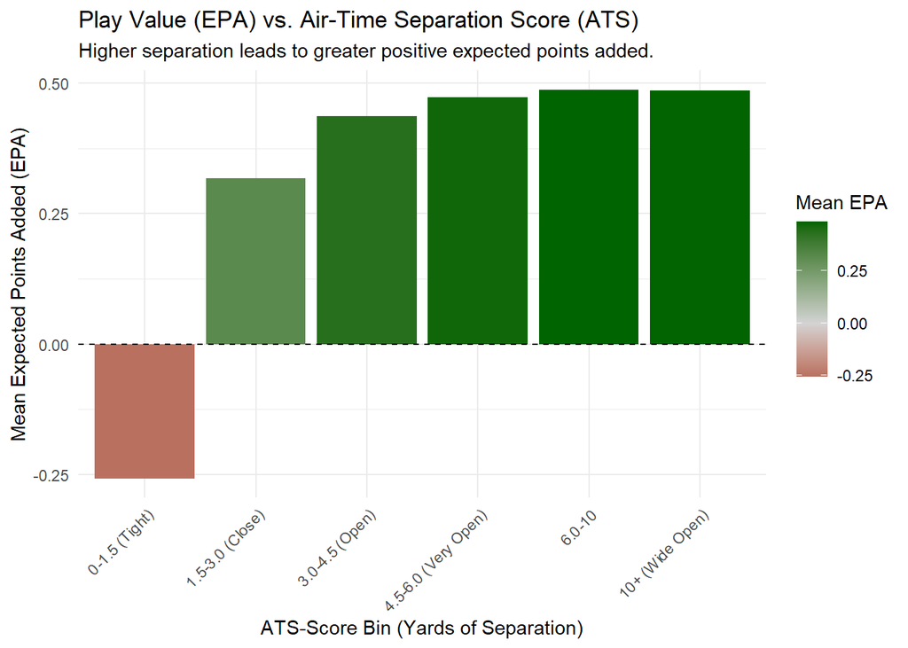

```r
# 1. Filter out non-pass outcomes (Sack/Scramble) as EPA for these are complex and can skew the plot.
df_epa_analysis = df_ats_analysis %>%
  filter(outcome_category %in% c("Completed", "Incomplete", "Interception"))

# 2. Create a binned ATS-Score variable for grouped analysis
df_epa_binned = df_epa_analysis %>%
  mutate(
    ats_bin = cut(ats_score,
                  breaks = c(0, 1.5, 3.0, 4.5, 6.0, 10, Inf),
                  labels = c("0-1.5 (Tight)", "1.5-3.0 (Close)", "3.0-4.5 (Open)", "4.5-6.0 (Very Open)", "6.0-10", "10+ (Wide Open)"),
                  right = FALSE)
  ) %>%
  # Filter out extreme EPA outliers (> 5 and < -5) for cleaner visualization
  filter(expected_points_added >= -5, expected_points_added <= 5)

# 3. Visualization: Mean EPA by ATS-Score Bin
plot_ats_epa = df_epa_binned %>%
  group_by(ats_bin) %>%
  summarise(
    Mean_EPA = mean(expected_points_added),
    .groups = 'drop'
  ) %>%
  ggplot(aes(x = ats_bin, y = Mean_EPA, fill = Mean_EPA)) +
  geom_bar(stat = "identity") +
  scale_fill_gradient2(low = "darkred", mid = "lightgray", high = "darkgreen", midpoint = 0) +
  geom_hline(yintercept = 0, linetype = "dashed", color = "black") +
  labs(
    title = "Play Value (EPA) vs. Air-Time Separation Score (ATS)",
    subtitle = "Higher separation leads to greater positive expected points added.",
    x = "ATS-Score Bin (Yards of Separation)",
    y = "Mean Expected Points Added (EPA)",
    fill = "Mean EPA"
  ) +
  theme_minimal() +
  theme(axis.text.x = element_text(angle = 45, hjust = 1))

print(plot_ats_epa)
```

```r
# ggsave("ats_score_vs_epa_bar.png", plot_ats_epa, width = 9, height = 6)
```

### Analysis 3: Ranking Targeted Receivers by ATS-Score

Now, calculate the average ATS-Score for every receiver who was targeted. Use the df_input_all data to identify the receiver’s name and position and then join it with the df_ats_analysis data.

```r
# 1. Get receiver name and position from the input data
df_receiver_info = df_input_all %>%
  filter(player_role == "Targeted Receiver") %>%
  # We only need one row per play/receiver for identification
  distinct(game_id, play_id, nfl_id, player_name, player_position) %>%
  # Rename nfl_id for clarity
  rename(receiver_nfl_id = nfl_id)

# 2. Join the ATS-Score with receiver information
df_receiver_ats = df_ats_analysis %>%
  left_join(df_receiver_info, by = c("game_id", "play_id"))

# 3. Calculate the average ATS-Score for each receiver (minimum 25 targets)
df_receiver_ranking = df_receiver_ats %>%
  # Filter only for Completed or Incomplete passes to focus on plays where the receiver had a chance
  filter(outcome_category %in% c("Completed", "Incomplete")) %>%
  group_by(receiver_nfl_id, player_name, player_position) %>%
  summarise(
    Total_Targets = n(),
    Avg_ATS_Score = mean(ats_score),
    Completion_Rate = sum(is_completed) / n(),
    .groups = 'drop'
  ) %>%
  # Filter for a minimum number of targets to ensure reliability
  filter(Total_Targets >= 25) %>%
  arrange(desc(Avg_ATS_Score))

# Display the top 15 receivers ranked by their average ATS-Score
cat("Top 15 Targeted Receivers by Average ATS-Score (Min. 25 Targets):\n")
```

```
## Top 15 Targeted Receivers by Average ATS-Score (Min. 25 Targets):
```

```r
df_receiver_ranking %>%
  head(15) %>%
  print()
```

```
## # A tibble: 15 × 6
##    receiver_nfl_id player_name       player_position Total_Targets Avg_ATS_Score
##              <dbl> <chr>             <chr>                   <int>         <dbl>
##  1           46071 Saquon Barkley    RB                         35          7.57
##  2           44927 Samaje Perine     RB                         26          6.37
##  3           52474 Antonio Gibson    RB                         27          6.17
##  4           44860 Joe Mixon         RB                         29          6.06
##  5           43293 Ezekiel Elliott   RB                         30          5.78
##  6           54556 Rachaad White     RB                         30          5.70
##  7           55872 Bijan Robinson    RB                         44          5.52
##  8           54528 James Cook        RB                         31          5.31
##  9           47807 Josh Jacobs       RB                         25          5.27
## 10           54501 Breece Hall       RB                         45          5.25
## 11           53454 Travis Etienne    RB                         25          5.25
## 12           53549 Rhamondre Steven… RB                         27          5.17
## 13           54621 Jerome Ford       RB                         35          5.12
## 14           55943 Tucker Kraft      TE                         33          4.99
## 15           47911 Tony Pollard      RB                         37          4.76
## # ℹ 1 more variable: Completion_Rate <dbl>
```

```r
# bottom 5
cat("\nBottom 5 Targeted Receivers by Average ATS-Score:\n")
```

```
##
## Bottom 5 Targeted Receivers by Average ATS-Score:
```

```r
df_receiver_ranking %>%
  tail(5) %>%
  print()
```

```
## # A tibble: 5 × 6
##   receiver_nfl_id player_name      player_position Total_Targets Avg_ATS_Score
##             <dbl> <chr>            <chr>                   <int>         <dbl>
## 1           44930 Josh Reynolds    WR                         55          2.49
## 2           53506 Josh Palmer      WR                         48          2.40
## 3           55939 Cedric Tillman   WR                         31          2.36
## 4           55885 Quentin Johnston WR                         52          2.35
## 5           42357 DeVante Parker   WR                         47          2.18
## # ℹ 1 more variable: Completion_Rate <dbl>
```

The top ten receivers by ATS-Score are overwhelmingly Running Backs (RBs). This confirms that RBs, who are targeted on shorter routes against often slower linebackers or in the open field, naturally achieve and maintain greater separation (e.g., Saquon Barkley at 7.57 yards). The metric is validated by the high Completion Rates of the high-ATS players (e.g., Samaje Perine at 0.962) and the low Completion Rates of the low-ATS players (e.g., Quentin Johnston at 0.538$. This confirms that ATS-Score effectively captures the difficulty of the catch opportunity created by the receiver.

Now, lets move on to the defenders

# Pursuit Efficiency Metric (PEM)

The Pursuit Efficiency Metric (PEM) quantifies how effectively a defender moves toward the ball landing location versus simply following the receiver. This metric is designed to separate good “man-cover” defenders from efficient “ball-hawks.” The formula is
$$\text{PEM} = \frac{\text{Distance to Ball Closed
(DBC)}}{\text{Distance Traveled (DT)}}$$

Where $\text{DBC}$ is the change in distance to the ball landing location, and $\text{DT}$ (Distance Traveled) is the path length:
$$\text{DT} = \sum_{t=1}^{N-1}
\sqrt{(\Delta x_t)^2 + (\Delta y_t)^2}$$

### Prepare Data for PEM Calculation

```r
# 1. Get Play Context (Ball Landing Location and Max Frame)
df_play_context = df_input_all %>% ##
  # Use distinct to get one row per play
  distinct(game_id, play_id, ball_land_x, ball_land_y, num_frames_output)

# 2. Join Defender Tracking Data with Play Context
# Use df_defender_tracking which contains x/y for defensive coverage players.
df_pem_tracking = df_defender_tracking %>%
  left_join(df_play_context, by = c("game_id", "play_id")) %>%
  # Remove plays where ball landing location is missing (i.e., not a pass attempt, though this should be rare after earlier filtering)
  filter(!is.na(ball_land_x))

# 3. Calculate Initial Distance to Ball Landing Spot (at frame_id = 1)
# This is needed for the Distance to Ball Closed (DBC) part of the metric.
df_pem_initial_distance = df_pem_tracking %>%
  filter(frame_id == 1) %>%
  mutate(
    initial_dist_to_ball = sqrt((defender_x - ball_land_x)^2 + (defender_y - ball_land_y)^2)
  ) %>%
  dplyr::select(game_id, play_id, nfl_id, initial_dist_to_ball)

# 4. Join initial distance back onto the main tracking data
df_pem_tracking = df_pem_tracking %>%
  left_join(df_pem_initial_distance, by = c("game_id", "play_id", "nfl_id"))

cat("Dimensions of df_pem_tracking:", dim(df_pem_tracking), "\n")
```

```
## Dimensions of df_pem_tracking: 402576 10
```

```r
df_pem_tracking %>% head() %>% print()
```

```
## # A tibble: 6 × 10
##    game_id play_id nfl_id frame_id defender_x defender_y ball_land_x ball_land_y
##      <dbl>   <dbl>  <dbl>    <dbl>      <dbl>      <dbl>       <dbl>       <dbl>
## 1   2.02e9     101  46137        1       56.2       17.3        63.3      -0.220
## 2   2.02e9     101  46137        2       56.6       16.9        63.3      -0.220
## 3   2.02e9     101  46137        3       57.1       16.5        63.3      -0.220
## 4   2.02e9     101  46137        4       57.5       16.0        63.3      -0.220
## 5   2.02e9     101  46137        5       57.9       15.6        63.3      -0.220
## 6   2.02e9     101  46137        6       58.3       15.1        63.3      -0.220
## # ℹ 2 more variables: num_frames_output <dbl>, initial_dist_to_ball <dbl>
```

### Calculate Distance Traveled (DT) and PEM

```r
# 1. Calculate Distance Traveled (DT)
# We need to calculate the frame-to-frame distance for each defender.
df_distance_traveled = df_pem_tracking %>%
  # Group by play and player
  group_by(game_id, play_id, nfl_id) %>%
  # Arrange by frame_id to ensure correct sequential calculation
  arrange(frame_id) %>%
  mutate(
    # Calculate difference in x and y position from the previous frame (Lag)
    dx = defender_x - lag(defender_x, default = first(defender_x)),
    dy = defender_y - lag(defender_y, default = first(defender_y)),
    # Distance moved in this frame interval
    dist_moved = sqrt(dx^2 + dy^2)
  ) %>%
  # The distance moved in the first frame (frame_id=1) is technically 0, but the lag function handles this by setting dx/dy to 0.

  # 2. Calculate Final Distance to Ball and Aggregate Components
  summarise(
    # DT: Total path length during ball flight (sum of dist_moved)
    dist_traveled = sum(dist_moved),
    # Final Dist to Ball: Defender's distance to landing spot at the final frame
    final_dist_to_ball = last(sqrt((defender_x - ball_land_x)^2 + (defender_y - ball_land_y)^2)),
    # Initial Dist to Ball is already calculated at frame 1 and consistent for the group
    initial_dist_to_ball = first(initial_dist_to_ball),
    .groups = 'drop'
  )

# 3. Calculate PEM
df_pem_final = df_distance_traveled %>%
  mutate(
    # Distance to Ball Closed (DBC)
    dist_closed = initial_dist_to_ball - final_dist_to_ball,
    # PEM: DBC / DT (DT must be > 0 to avoid division by zero, use 0 for players who didn't move)
    pem_score = case_when(
      dist_traveled > 0 ~ dist_closed / dist_traveled,
      TRUE ~ 0 # PEM is 0 if no distance was traveled
    )
  ) %>%
  # Filter out players who were too far away to matter (e.g., initial distance > 50 yards)
  filter(initial_dist_to_ball < 50)

cat("Top 5 Defender Pursuits by PEM Score:\n")
```

```
## Top 5 Defender Pursuits by PEM Score:
```

```r
df_pem_final %>%
  arrange(desc(pem_score)) %>%
  head() %>%
  print()
```

```
## # A tibble: 6 × 8
##     game_id play_id nfl_id dist_traveled final_dist_to_ball initial_dist_to_ball
##       <dbl>   <dbl>  <dbl>         <dbl>              <dbl>                <dbl>
## 1    2.02e9    2869  47788          1.75               1.64                 3.39
## 2    2.02e9    3099  52445          6.26               3.07                 9.33
## 3    2.02e9    1797  45021          3.41               3.62                 7.03
## 4    2.02e9    2126  42816         11.2                1.50                12.7
## 5    2.02e9    1942  52535          5.14               3.18                 8.32
## 6    2.02e9     479  54936          6.21               1.77                 7.98
## # ℹ 2 more variables: dist_closed <dbl>, pem_score <dbl>
```

### Analysis 4: PEM Validation and Coverage Strategy Comparison

This analysis validates the PEM by comparing its distribution across pass outcomes and then explores differences in pursuit efficiency based on the defensive strategy (Man vs. Zone coverage). A higher PEM score (closer to 1.0) indicates more efficient pursuit of the ball landing spot.

```r
# 1. Merge PEM scores with the Supplementary Play Data
df_pem_analysis = df_pem_final %>%
  inner_join(df_plays, by = c("game_id", "play_id")) %>%
  # Apply the same outcome categorization used for ATS-Score
  mutate(
    outcome_category = case_when(
      pass_result == "C" ~ "Completed",
      pass_result == "I" ~ "Incomplete",
      pass_result == "IN" ~ "Interception",
      TRUE ~ "Other" # Handles Sacks/Scrambles
    )
  ) %>%
  # Filter only for plays that are relevant to defense success
  filter(outcome_category %in% c("Completed", "Incomplete", "Interception"))

# 2. Calculate Mean PEM by Outcome Category (Validation)
pem_outcome_summary = df_pem_analysis %>%
  group_by(outcome_category) %>%
  summarise(
    N = n(),
    Mean_PEM = mean(pem_score),
    Median_PEM = median(pem_score),
    .groups = 'drop'
  )

cat("Mean PEM Score by Play Outcome:\n")
```

```
## Mean PEM Score by Play Outcome:
```

```r
pem_outcome_summary %>% print()
```

```
## # A tibble: 3 × 4
##   outcome_category     N Mean_PEM Median_PEM
##   <chr>            <int>    <dbl>      <dbl>
## 1 Completed        20363    0.367      0.654
## 2 Incomplete       10449    0.480      0.775
## 3 Interception      1125    0.505      0.770
```

```r
# 3. Calculate Mean PEM by Coverage Strategy (Strategy Analysis)
pem_coverage_summary = df_pem_analysis %>%
  filter(team_coverage_man_zone %in% c("MAN_COVERAGE", "ZONE_COVERAGE")) %>%
  group_by(team_coverage_man_zone) %>%
  summarise(
    N = n(),
    Mean_PEM = mean(pem_score),
    Median_PEM = median(pem_score),
    .groups = 'drop'
  )

cat("\nMean PEM Score by Coverage Strategy:\n")
```

```
##
## Mean PEM Score by Coverage Strategy:
```

```r
pem_coverage_summary %>% print()
```

```
## # A tibble: 2 × 4
##   team_coverage_man_zone     N Mean_PEM Median_PEM
##   <chr>                  <int>    <dbl>      <dbl>
## 1 MAN_COVERAGE            9733    0.355      0.680
## 2 ZONE_COVERAGE          22200    0.432      0.707
```

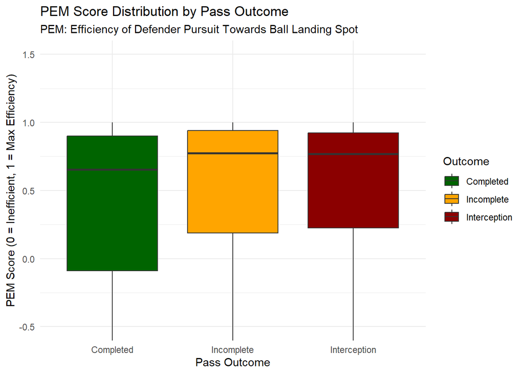

```r
# 4. Visualization: Box Plot of PEM vs. Outcome
plot_pem_outcome = df_pem_analysis %>%
  ggplot(aes(x = outcome_category, y = pem_score, fill = outcome_category)) +
  geom_boxplot(outlier.shape = NA) + # Hide outliers for clarity
  scale_fill_manual(values = c("Completed" = "darkgreen", "Incomplete" = "orange", "Interception" = "darkred")) +
  labs(
    title = "PEM Score Distribution by Pass Outcome",
    subtitle = "PEM: Efficiency of Defender Pursuit Towards Ball Landing Spot",
    x = "Pass Outcome",
    y = "PEM Score (0 = Inefficient, 1 = Max Efficiency)",
    fill = "Outcome"
  ) +
  theme_minimal() +
  # Limit y-axis to focus on the bulk of the data
  coord_cartesian(ylim = c(-0.5, 1.5))

print(plot_pem_outcome)
```

```r
#ggsave("pem_score_by_outcome_boxplot.png", plot_pem_outcome, width = 8, height = 5)
```

The metric is validated as intended. Plays where the defense is successful (Incomplete or Interception) feature a significantly higher Mean PEM score. This means that when the defense efficiently tracks the ball’s final landing location, they are much more likely to prevent a completion. Also, when looking at the strategies, we see that defenders in ZONE COVERAGE show a significantly higher Mean PEM score (0.432) compared to those in MAN COVERAGE (0.355).

### Analysis 5: Ranking Defensive Players by PEM

```r
# 1. Get defender name and position from the input data
df_defender_info = df_input_all %>%
  filter(player_role == "Defensive Coverage") %>%
  distinct(nfl_id, player_name, player_position)

# 2. Join the PEM Score with defender information
# Since df_pem_final is player/play level, join this to get the names
df_defender_pem = df_pem_final %>%
  inner_join(df_defender_info, by = "nfl_id")

# 3. Calculate the average PEM Score for each defender (minimum 50 plays)
df_defender_ranking = df_defender_pem %>%
  group_by(nfl_id, player_name, player_position) %>%
  summarise(
    Total_Plays = n(),
    Avg_PEM_Score = mean(pem_score),
    .groups = 'drop'
  ) %>%
  # Filter for a minimum number of plays to ensure reliability
  filter(Total_Plays >= 50) %>%
  arrange(desc(Avg_PEM_Score))

# Display the top 10 defenders ranked by their average PEM Score
cat("Top 10 Defensive Players by Average PEM Score (Min. 50 Plays):\n")
```

```
## Top 10 Defensive Players by Average PEM Score (Min. 50 Plays):
```

```r
df_defender_ranking %>%
  head(10) %>%
  print()
```

```
## # A tibble: 10 × 5
##    nfl_id player_name        player_position Total_Plays Avg_PEM_Score
##     <dbl> <chr>              <chr>                 <int>         <dbl>
##  1  56527 Ivan Pace Jr.      ILB                      59         0.690
##  2  54808 Reed Blankenship   FS                      119         0.686
##  3  52844 Christian Rozeboom ILB                      84         0.659
##  4  46123 Jessie Bates       SS                      127         0.650
##  5  42391 Denzel Perryman    ILB                      69         0.636
##  6  46077 Roquan Smith       MLB                     158         0.635
##  7  47913 Drue Tranquill     ILB                      60         0.627
##  8  47871 Cody Barton        ILB                      94         0.621
##  9  55882 Jack Campbell      MLB                      78         0.618
## 10  41243 C.J. Mosley        ILB                     121         0.616
```

```r
# Display the bottom 5
cat("\nBottom 5 Defensive Players by Average PEM Score:\n")
```

```
##
## Bottom 5 Defensive Players by Average PEM Score:
```

```r
df_defender_ranking %>%
  tail(5) %>%
  print()
```

```
## # A tibble: 5 × 5
##   nfl_id player_name      player_position Total_Plays Avg_PEM_Score
##    <dbl> <chr>            <chr>                 <int>         <dbl>
## 1  44902 Shaquill Griffin CB                       76        0.155
## 2  44893 Fabian Moreau    CB                      119        0.151
## 3  46652 Chandon Sullivan CB                       60        0.120
## 4  46699 Dee Delaney      CB                       72        0.104
## 5  44818 Jamal Adams      OLB                      70        0.0727
```

It seems like players with the highest PEM scores are primarily Linebackers (ILB/MLB) and Safeties (FS/SS) (e.g., Ivan Pace Jr., Jessie Bates). These positions are often responsible for deep zone coverage, which requires them to efficiently pursue the ball’s target area. And players with the lowest PEM scores are mainly Cornerbacks (CB) in man coverage (e.g., Shaquill Griffin, Fabian Moreau). Their objective is to maintain proximity to the receiver, often leading to movement that is not directionally efficient toward the final ball location, resulting in a lower PEM.

# Spatial Matchup Value (SMV)

Spatial Matchup Value (SMV), is a powerful composite metric designed to assess the balance of a specific receiver-closest defender matchup. The SMV is calculated simply as the difference between the receiver’s separation ability (ATS-Score) and the closest defender’s pursuit efficiency (PEM-Score), with the formula:
$$\text{SMV} = \text{ATS Score}_{\text{Receiver}} -
\text{PEM Score}_{\text{Closest Defender}}$$

A high positive SMV indicates a favorable matchup for the offense (high separation, low defensive efficiency), and a low negative SMV indicates a favorable matchup for the defense

### Calculate Spatial Matchup Value (SMV)

```r
# 1. Identify the Closest Defender for each play
# Find the defender associated with the overall minimum separation (min_separation_achieved)
df_closest_defender_id = df_min_separation %>%
  group_by(game_id, play_id) %>%
  # Slice_min takes the row where min_separation is lowest
  slice_min(min_separation, n = 1, with_ties = FALSE) %>%
  dplyr::select(game_id, play_id, closest_defender_id)

# 3. Join the PEM Score of the Closest Defender (player/play-level defense metric)
# rename nfl_id in df_pem_final to match closest_defender_id for the join.
df_matchup_data = df_ats_score %>%
  inner_join(
    df_pem_final %>% dplyr::select(game_id, play_id, nfl_id, pem_score),
    by = c("game_id", "play_id", "closest_defender_id" = "nfl_id")
  ) %>%
  rename(closest_defender_pem = pem_score)

# 4. Calculate the Spatial Matchup Value (SMV)
df_smv_score = df_matchup_data %>%
  mutate(
    smv_score = ats_score - closest_defender_pem
  )

# 5. Analyze SMV by Play Outcome
smv_summary = df_smv_score %>%
  inner_join(
    df_ats_analysis %>% dplyr::select(game_id, play_id, outcome_category),
    by = c("game_id", "play_id")
  ) %>%
  filter(outcome_category %in% c("Completed", "Incomplete", "Interception")) %>%
  group_by(outcome_category) %>%
  summarise(
    N = n(),
    Mean_SMV = mean(smv_score),
    Median_SMV = median(smv_score),
    .groups = 'drop'
  )

cat("Mean Spatial Matchup Value (SMV) by Play Outcome:\n")
```

```
## Mean Spatial Matchup Value (SMV) by Play Outcome:
```

```r
smv_summary %>% print()
```

```
## # A tibble: 3 × 4
##   outcome_category     N Mean_SMV Median_SMV
##   <chr>            <int>    <dbl>      <dbl>
## 1 Completed         8692     3.52      3.05
## 2 Incomplete        3966     1.75      0.973
## 3 Interception       335     1.82      1.50
```

# Multi-Level Model for Completions Prevented Above Replacement

Using a structure much like that used by Desphande and Wyner, we’ll use the metrics defined above, along with the additional provided context of each play, including encodings for defensive alignment, offensive routes, and other play indicators to define a “replacement-level” for defenders, which will then be used to determine which players exceed those replacement-level metrics. The baseline modeling will be done using two methods. First, a standard GLM will be leveraged to define the log-odds of an incompletion for a baseline defender, which will then be used to model player-specific attributes. A similar process will also be done using a Random Forest approach. With these two routes, we’ll seek to analyze which players deviate the greatest between the GLM and the Random Forest, and if the two different models produce comparable results when modeling the baseline.

In order to begin modeling, we’ll combine several of the data frames composed throughout the derivation of ATS, PEM, and SMV, along with the provided supplementary data. Our response will *outcome_category* used prior, including categories for a completion (encoded as 0), or an incompletion or interception (1). Clearly, an interception intuitively would be worth more, for a defender, than a standard incompletion, but for the sake of this modeling exercise, we’ll define a binary category which lumps interceptions into incompletions.

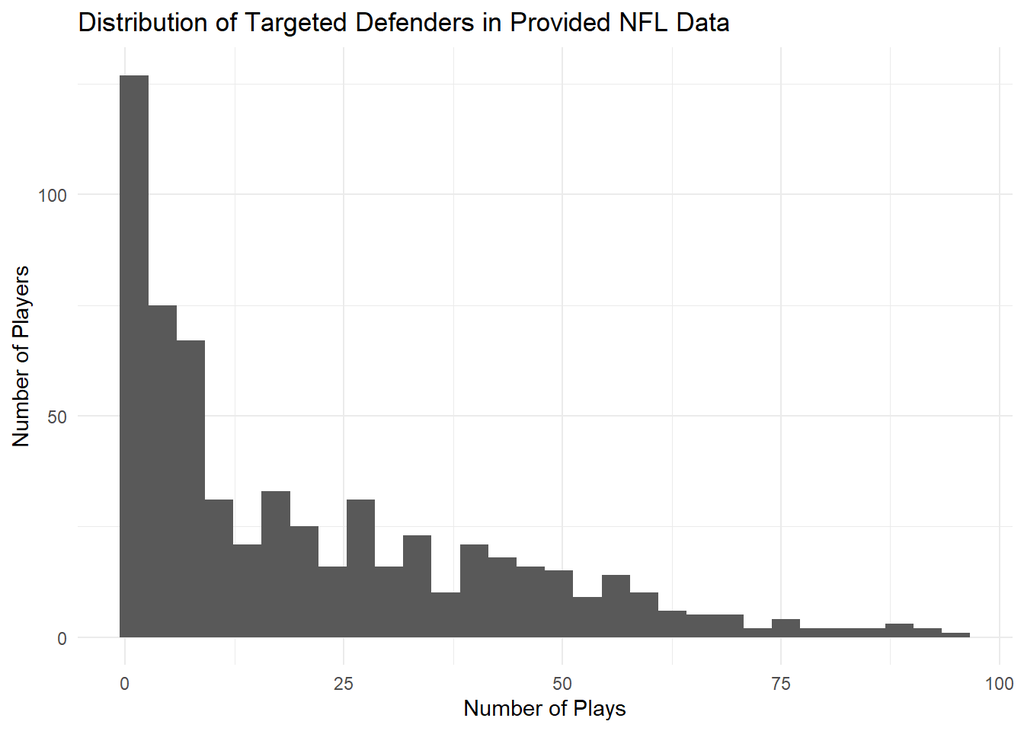

```r
ggplot(df_total %>% group_by(closest_defender_id) %>% count() %>% arrange(desc(n)) , aes(x = n)) +
  geom_histogram() +
  labs(
    title = "Distribution of Targeted Defenders in Provided NFL Data"
  ) +
  xlab("Number of Plays") +
  ylab("Number of Players") +
  theme_minimal()
```

A broad proportion of defenders targeted in the dataset typically have 45 or less targets throughout the dataset, with 54.8% of plays involving players which fall into this category. As such, we’ll define 45 plays as our threshold for a “replacement-level” player versus a “top” defender.

```
## [1] 7114
```

Our first approach sees us model the baseline probability that a play ends in an incompletion with an generalized additive model. We’ll then do the same estimation with a Random Forest model. From this, we’ll compare the two different modeling approaches based on Brier score and Binary Cross-Entropy (BCE) loss.

```r
# GAM
hgam_fit = gam(
  formula = pass_result ~ ats_score + min_separation_achieved + final_dist_to_ball +
    dist_traveled + initial_dist_to_ball + dist_closed + pem_score + smv_score + pass_location_type +
    route_of_targeted_receiver + defenders_in_the_box + team_coverage_type + dropback_type,
  data = df_total, family = binomial(link="logit"))
gam_baseline = predict(hgam_fit, newdata = df_total, type="response")
# Example output with GAM baseline predictions
df_total %>%
  mutate(
    baseline_gam_prob = gam_baseline
  ) %>%
  select(c(game_id, play_id, ats_score, smv_score, pass_result, baseline_gam_prob)) %>%
  head(10)
```

```
## # A tibble: 10 × 6
##       game_id play_id ats_score smv_score pass_result baseline_gam_prob
##         <dbl>   <dbl>     <dbl>     <dbl>       <dbl>         <dbl[1d]>
##  1 2023090700    3461      3.31     2.86            0            0.235
##  2 2023090700     461      4.84     5.13            0            0.140
##  3 2023090700    1940      5.37     5.14            1            0.184
##  4 2023090700    1711      6.71     5.71            0            0.243
##  5 2023090700    1588      1.17     0.184           1            0.680
##  6 2023090700     101      2.60     1.63            1            0.610
##  7 2023090700    3566      2.16     2.47            0            0.394
##  8 2023090700     902      2.57     1.62            1            0.328
##  9 2023090700    1069      5.87     6.05            0            0.0945
## 10 2023090700    2261      1.87     1.08            0            0.419
```

```r
rf_fit <- ranger(
  formula = pass_result ~ ats_score + min_separation_achieved + final_dist_to_ball +
    dist_traveled + initial_dist_to_ball + dist_closed + pem_score + smv_score + pass_location_type +
    route_of_targeted_receiver + defenders_in_the_box + team_coverage_type + dropback_type,
  data = df_total,
  probability = TRUE,  # Essential for getting probabilities instead of classes
  num.trees = 250,
  importance = "impurity",  # Optional: to get variable importance
  seed = 42
)

rf_baseline = predict(rf_fit, data = df_total, type="response")$predictions[,2]
model_comp = df_total %>%
  mutate(
    baseline_gam_prob = gam_baseline,
    baseline_rf_prob = rf_baseline
  ) %>%
  select(c(game_id, play_id, ats_score, smv_score, pass_result, baseline_gam_prob, baseline_rf_prob))
model_comp %>%
  head(10)
```

```
## # A tibble: 10 × 7
##       game_id play_id ats_score smv_score pass_result baseline_gam_prob
##         <dbl>   <dbl>     <dbl>     <dbl>       <dbl>         <dbl[1d]>
##  1 2023090700    3461      3.31     2.86            0            0.235
##  2 2023090700     461      4.84     5.13            0            0.140
##  3 2023090700    1940      5.37     5.14            1            0.184
##  4 2023090700    1711      6.71     5.71            0            0.243
##  5 2023090700    1588      1.17     0.184           1            0.680
##  6 2023090700     101      2.60     1.63            1            0.610
##  7 2023090700    3566      2.16     2.47            0            0.394
##  8 2023090700     902      2.57     1.62            1            0.328
##  9 2023090700    1069      5.87     6.05            0            0.0945
## 10 2023090700    2261      1.87     1.08            0            0.419
## # ℹ 1 more variable: baseline_rf_prob <dbl>
```

```r
print(str_c("Binary Cross-Entropy loss with GAM approach: ", as.character(round(mean(model_comp %>%
  mutate(bce_loss = -((pass_result*log(baseline_gam_prob))+((1-pass_result)*log(1-baseline_gam_prob)))) %>% pull(bce_loss)), 4))))
```

```
## [1] "Binary Cross-Entropy loss with GAM approach: 0.5434"
```

```r
print(str_c("Brier loss with GAM approach: ", as.character(round(mean(model_comp %>%
  mutate(brier_loss_gam = (baseline_gam_prob - pass_result)^2) %>% pull(brier_loss_gam)), 4))))
```

```
## [1] "Brier loss with GAM approach: 0.1761"
```

```r
print(str_c("Binary Cross-Entropy loss with Random Forest approach: ", as.character(round(mean(model_comp %>%
  mutate(bce_loss = -((pass_result*log(baseline_rf_prob))+((1-pass_result)*log(1-baseline_rf_prob)))) %>% pull(bce_loss)), 4))))
```

```
## [1] "Binary Cross-Entropy loss with Random Forest approach: 0.2126"
```

```r
print(str_c("Brier loss with Random Forest approach: ", as.character(round(mean(model_comp %>%
  mutate(brier_loss_rf = (baseline_rf_prob - pass_result)^2) %>% pull(brier_loss_rf)), 4))))
```

```
## [1] "Brier loss with Random Forest approach: 0.0509"
```

From the results above, we see that the Random Forest approach outperforms the GAM model when estimating the probability of an incompletion. Particularly, the Random Forest model stands out in regard to BCE loss, with 0.21 compared to 0.54 with the GAM approach. This trend is seen in the Brier score as well, with 0.05 compared to 0.176. This motivates our choice to move forward with the baseline estimations provided by the Random Forest classifier; however, we’ll see later that this actually results in somewhat unreasonable results when compared to what we get with GAM baselines.

With that said, we can now use these baseline values with the defender IDs to draw out player-specifc responses, alongside team-level play attributes like the coverage type of the defense and the route that the target receiver is running.

```r
df_total_w_baseline = df_total %>%
  mutate(
    baseline = rf_baseline
  )
# Multi-level model with baseline projections and player interactions
multilevel_fit <-
  glmer(formula = pass_result ~ 1 + (1 | closest_defender_id) + (1 | team_coverage_type) + (1 | route_of_targeted_receiver) + baseline,
        family = binomial(link = "logit"), # get logits
        data = df_total_w_baseline)
```

We’ll now extract the deviations for each *closest_defender_id* that we applied our multi-level model to, and then calculate the replacement-level probability of an incompletion and the player’s probability of causing an incompletion based on their deviation. From this, we’ll find the difference between the two calculations, highlighting a defender’s performance above/below a replacement-level player.

```
## [1] "Deviation of replacement-level defender: 0.00650196753247922"
```

```r
preds = predict(object = multilevel_fit,
        newdata = df_total_w_baseline,
        type = "link")
inc_or = df_total_w_baseline %>% mutate(log_odds = preds)

inc_or = inc_or |>
  dplyr::left_join(inc_u %>%
                     dplyr::select(defender, u) %>%
                     rename(closest_defender_id = defender),
                   by = "closest_defender_id") %>%
  rename(defender = closest_defender_id) %>%
  dplyr::mutate(repl_log_odds = log_odds - u + repl_u)
inc_or =
  inc_or %>%
  dplyr::mutate(
    fitted_prob = 1/(1 + exp(-1 * log_odds)), # converting log-odds to probabilities
    repl_prob = 1/(1 + exp(-1 * repl_log_odds)), # computing counter-factual probabilities
    value = fitted_prob - repl_prob # simple
  )
```

```
## # A tibble: 20 × 3
##    player_name      player_position value
##    <chr>            <chr>           <dbl>
##  1 James Bradberry  CB              0.803
##  2 Daxton Hill      CB              0.524
##  3 Alex Austin      CB              0.516
##  4 Ernest Jones     MLB             0.493
##  5 Adoree' Jackson  CB              0.483
##  6 Jerry Jacobs     CB              0.453
##  7 Denzel Ward      CB              0.440
##  8 Logan Wilson     MLB             0.410
##  9 Jaylon Jones     CB              0.394
## 10 Christian Harris OLB             0.338
## 11 Rayshawn Jenkins SS              0.333
## 12 Jeff Okudah      CB              0.328
## 13 Dee Delaney      CB              0.318
## 14 Tyson Campbell   CB              0.300
## 15 Jamal Adams      OLB             0.285
## 16 Jordan Hicks     ILB             0.282
## 17 Markquese Bell   SS              0.279
## 18 L'Jarius Sneed   CB              0.258
## 19 E.J. Speed       MLB             0.252
## 20 Blake Cashman    ILB             0.240
```

```
## [1] "Deviation of replacement-level defender: -0.000246503770894172"
```

```
## # A tibble: 20 × 3
##    player_name         player_position value
##    <chr>               <chr>           <dbl>
##  1 Devon Witherspoon   CB              0.574
##  2 DaRon Bland         CB              0.529
##  3 Adoree' Jackson     CB              0.529
##  4 Levi Wallace        CB              0.515
##  5 Rayshawn Jenkins    SS              0.505
##  6 Deonte Banks        CB              0.464
##  7 Denzel Ward         CB              0.444
##  8 Jaylon Johnson      CB              0.438
##  9 Ja'Quan McMillian   CB              0.438
## 10 Greg Newsome II     CB              0.438
## 11 Stephon Gilmore     CB              0.435
## 12 L'Jarius Sneed      CB              0.430
## 13 Darious Williams    CB              0.415
## 14 Kyle Hamilton       SS              0.414
## 15 Dre Greenlaw        ILB             0.385
## 16 Ahkello Witherspoon CB              0.373
## 17 Amik Robertson      CB              0.344
## 18 Ja'Sir Taylor       CB              0.303
## 19 Asante Samuel       CB              0.286
## 20 Devin White         OLB             0.279
```

To get points saved above replacement, we have to consider EPA which is estimated points allowed. The previous model used a binary outcome of incompletion or not to measure success, but to get points saved, we shift to using Points modeled by a Gaussian instead. The approach to get points saved above replacement will be to calculate the EPA from predictors from the GAM regression model and then find EPA if every pass was completed, then subtracting expected points added from this to get overall points saved.

```r
df_plays_subset <- df_plays %>%
  select(game_id, play_id, expected_points, expected_points_added, pass_result)
df_final <- df_total %>%
  select(-pass_result) %>%
  left_join(df_plays_subset, by = c("game_id", "play_id"))


df_final <- df_final %>%
  mutate(
    # Outcome category from pass_result
    outcome_category = case_when(
      pass_result == "C"  ~ "Completed",
      pass_result == "I"  ~ "Incomplete",
      pass_result == "IN" ~ "Interception",
      TRUE                ~ "Other"
    ),
    outcome_category = factor(outcome_category,
                              levels = c("Completed","Incomplete","Interception","Other")),

    # Categorical encodings as factors (they look numeric in your snippet)
    pass_location_type      = factor(pass_location_type),
    route_of_targeted_receiver = factor(route_of_targeted_receiver),
    defenders_in_the_box    = factor(defenders_in_the_box),
    team_coverage_type      = factor(team_coverage_type),
    dropback_type           = factor(dropback_type)
  )

df_model <- df_final %>%
  filter(outcome_category %in% c("Completed", "Incomplete", "Interception")) %>%
  filter(!is.na(expected_points_added))

df_completed <- df_model %>%
  filter(outcome_category == "Completed")
```

Now we fit the model to find what the EPA would be if the pass was completed

```r
gam_epa <- gam(
  expected_points_added ~ ats_score + min_separation_achieved + final_dist_to_ball + dist_traveled + initial_dist_to_ball + dist_closed + pem_score + smv_score + pass_location_type + route_of_targeted_receiver + defenders_in_the_box + team_coverage_type + dropback_type,
  data   = df_completed,
  family = gaussian()
)

summary(gam_epa)
```

```
##
## Family: gaussian
## Link function: identity
##
## Formula:
## expected_points_added ~ ats_score + min_separation_achieved +
##     final_dist_to_ball + dist_traveled + initial_dist_to_ball +
##     dist_closed + pem_score + smv_score + pass_location_type +
##     route_of_targeted_receiver + defenders_in_the_box + team_coverage_type +
##     dropback_type
##
## Parametric coefficients:
##                               Estimate Std. Error t value Pr(>|t|)
## (Intercept)                   0.438864   0.627462   0.699  0.48430
## ats_score                    -0.118213   0.017419  -6.787 1.22e-11 ***
## min_separation_achieved       0.047354   0.018960   2.498  0.01252 *
## final_dist_to_ball            0.043104   0.006159   6.999 2.78e-12 ***
## dist_traveled                 0.081435   0.010790   7.547 4.90e-14 ***
## initial_dist_to_ball          0.042059   0.005858   7.179 7.58e-13 ***
## dist_closed                  -0.001044   0.007233  -0.144  0.88522
## pem_score                    -0.150953   0.030287  -4.984 6.35e-07 ***
## smv_score                     0.032739   0.017320   1.890  0.05876 .
## pass_location_type2           0.219288   0.080240   2.733  0.00629 **
## pass_location_type3           0.085307   0.073509   1.160  0.24588
## pass_location_type4           1.398197   0.767272   1.822  0.06844 .
## route_of_targeted_receiver2   1.067270   0.097802  10.913  < 2e-16 ***
## route_of_targeted_receiver3   0.187245   0.074746   2.505  0.01226 *
## route_of_targeted_receiver4  -0.388656   0.071675  -5.422 6.04e-08 ***
## route_of_targeted_receiver5   1.026481   0.086880  11.815  < 2e-16 ***
## route_of_targeted_receiver6   0.281390   0.067558   4.165 3.14e-05 ***
## route_of_targeted_receiver7   0.655217   0.076238   8.594  < 2e-16 ***
## route_of_targeted_receiver8   0.088286   0.070387   1.254  0.20977
## route_of_targeted_receiver9   1.342293   0.084574  15.871  < 2e-16 ***
## route_of_targeted_receiver10 -0.476200   0.108760  -4.378 1.21e-05 ***
## route_of_targeted_receiver11  0.473332   0.075390   6.278 3.58e-10 ***
## route_of_targeted_receiver12  0.918498   0.193089   4.757 2.00e-06 ***
## defenders_in_the_box2         0.067123   0.657399   0.102  0.91868
## defenders_in_the_box3        -0.369352   0.621606  -0.594  0.55240
## defenders_in_the_box4        -0.397547   0.611264  -0.650  0.51547
## defenders_in_the_box5        -0.247298   0.612090  -0.404  0.68621
```

[output cut: 10 more lines]

```
## team_coverage_type6          -0.380735   0.068446  -5.563 2.74e-08 ***
## team_coverage_type7          -0.415076   0.072827  -5.699 1.24e-08 ***
## team_coverage_type8          -1.679685   0.291979  -5.753 9.08e-09 ***
## dropback_type2                0.026542   0.107758   0.246  0.80545
## dropback_type3                0.530030   0.104711   5.062 4.24e-07 ***
## dropback_type4                0.182194   0.547502   0.333  0.73931
## dropback_type5                0.048147   0.188320   0.256  0.79822
## dropback_type6                0.143313   0.088171   1.625  0.10412
## ---
## Signif. codes:  0 '***' 0.001 '**' 0.01 '*' 0.05 '.' 0.1 ' ' 1
##
##
## Rank: 43/45
## R-sq.(adj) =  0.337   Deviance explained =   34%
## GCV = 1.1761  Scale est. = 1.1703    n = 8692
```

We can see the significant predictors from this model as well, like ats, dist_traveled and pem, which connects our previous metrics to calculating this one.

The points saved is calculated by taking the epa if completed - the expected points added, effectively leaving us with how many points were saved if the pass was not complete(interception or incomplete)

```r
df_model <- df_model %>%
  mutate(
    # Counterfactual EPA if this pass were completed
    epa_if_completed = predict(gam_epa, newdata = df_model),
    # Defensive points saved on the actual outcome
    def_points_saved = epa_if_completed - expected_points_added
  )

# Quick sanity check by outcome
df_model %>%
  group_by(outcome_category) %>%
  summarise(
    mean_epa_if_completed = mean(epa_if_completed),
    mean_actual_epa      = mean(expected_points_added),
    mean_points_saved    = mean(def_points_saved),
    .groups = "drop"
  )
```

```
## # A tibble: 3 × 4
##   outcome_category mean_epa_if_completed mean_actual_epa mean_points_saved
##   <fct>                            <dbl>           <dbl>             <dbl>
## 1 Completed                        0.959           0.959          2.74e-15
## 2 Incomplete                       1.56           -0.983          2.54e+ 0
## 3 Interception                     1.53           -4.70           6.23e+ 0
```

Now using the Points saved, we fit another regression model to fit the replacement level of a player for points saved. Using this replacement level, we will calculate players above and below this level to find the most effective players at saving points and the least effective

```r
gam_ps <- gam(
  def_points_saved ~ ats_score + min_separation_achieved + final_dist_to_ball + dist_traveled + initial_dist_to_ball + dist_closed + pem_score + smv_score + pass_location_type + route_of_targeted_receiver + defenders_in_the_box + team_coverage_type + dropback_type,
  data   = df_model,
  family = gaussian()
)

df_model <- df_model %>%
  mutate(
    baseline_ps = predict(gam_ps, newdata = df_model)
  )

df_model <- df_model %>%
  mutate(
    closest_defender_id = as.numeric(closest_defender_id)
  )

#mixed model uses points saved and learns baseline
ml_points <- lmer(
  def_points_saved ~ baseline_ps +
    (1 | closest_defender_id) +
    (1 | team_coverage_type) +
    (1 | route_of_targeted_receiver),
  data = df_model
)

summary(ml_points)
```

```
## Linear mixed model fit by REML ['lmerMod']
## Formula: def_points_saved ~ baseline_ps + (1 | closest_defender_id) +
##     (1 | team_coverage_type) + (1 | route_of_targeted_receiver)
##    Data: df_model
##
## REML criterion at convergence: 49793.9
##
## Scaled residuals:
##     Min      1Q  Median      3Q     Max
## -4.9570 -0.5678  0.0306  0.5217  7.3977
##
## Random effects:
##  Groups                     Name        Variance Std.Dev.
##  closest_defender_id        (Intercept) 0.0111   0.1054
##  route_of_targeted_receiver (Intercept) 0.0000   0.0000
##  team_coverage_type         (Intercept) 0.0000   0.0000
##  Residual                               2.6908   1.6404
## Number of obs: 12993, groups:
## closest_defender_id, 612; route_of_targeted_receiver, 12; team_coverage_type, 8
##
## Fixed effects:
##              Estimate Std. Error t value
## (Intercept) -0.001817   0.021981  -0.083
## baseline_ps  0.998686   0.016722  59.724
##
## Correlation of Fixed Effects:
##             (Intr)
## baseline_ps -0.706
## optimizer (nloptwrap) convergence code: 0 (OK)
## boundary (singular) fit: see help('isSingular')
```

```r
def_u <- ranef(ml_points)$closest_defender_id %>%
  tibble::rownames_to_column("closest_defender_id") %>%
  mutate(
    closest_defender_id = as.numeric(closest_defender_id)
  ) %>%
  rename(u = `(Intercept)`)

# Number of plays per defender
def_counts <- df_model %>%
  group_by(closest_defender_id) %>%
  summarise(
    n_plays = n(),
    .groups = "drop"
  )

def_u_counts <- def_u %>%
  left_join(def_counts, by = "closest_defender_id")

#defenders with fewer than 45 plays filtered
repl_pool <- def_u_counts %>%
  filter(n_plays < 45)

# Replacement-level effect: e.g., 20th percentile of that pool
repl_u <- quantile(repl_pool$u, probs = 0.2, na.rm = TRUE)

print(paste("Replacement-level random effect (u):", round(repl_u, 4)))
```

```
## [1] "Replacement-level random effect (u): -0.0153"
```

```r
df_value <- df_model %>%
  left_join(def_u, by = "closest_defender_id") %>%
  mutate(
    # Defenders with no estimated effect get 0 (full shrinkage)
    u = ifelse(is.na(u), 0, u),
    repl_u = as.numeric(repl_u),

    # Expected points saved for this defender vs replacement
    fitted_ps = baseline_ps + u,
    repl_ps   = baseline_ps + repl_u,
    value_ps  = fitted_ps - repl_ps   # points saved above replacement on this play
  )

df_defender_info <- df_input_all %>%
  filter(player_role == "Defensive Coverage") %>%
  distinct(nfl_id, player_name, player_position)

player_value_points <- df_value %>%
  group_by(closest_defender_id) %>%
  summarise(
    n_plays           = n(),
    total_points_saved_above_repl = sum(value_ps),
    avg_points_saved_above_repl   = mean(value_ps),
    .groups = "drop"
  ) %>%
  left_join(df_defender_info,
            by = c("closest_defender_id" = "nfl_id")) %>%
  # Require a minimum number of plays for stability
  filter(n_plays >= 45) %>%
  arrange(desc(total_points_saved_above_repl))

cat("Top 20 defenders by total points saved above replacement:\n")
```

```
## Top 20 defenders by total points saved above replacement:
```

```r
top_points = player_value_points %>%
  head(20) %>%
  select(player_name, player_position, n_plays,
         total_points_saved_above_repl,
         avg_points_saved_above_repl) %>%
  print()
```

```
## # A tibble: 20 × 5
##    player_name         player_position n_plays total_points_saved_above_repl
##    <chr>               <chr>             <int>                         <dbl>
##  1 DaRon Bland         CB                   81                         14.8
##  2 Paulson Adebo       CB                   80                          9.49
##  3 Ahkello Witherspoon CB                   90                          8.59
##  4 Deommodore Lenoir   CB                   74                          7.67
##  5 Darious Williams    CB                   77                          6.72
##  6 Cordale Flott       CB                   47                          6.14
##  7 Denzel Ward         CB                   51                          6.06
##  8 Foye Oluokun        OLB                  54                          5.60
##  9 L'Jarius Sneed      CB                   68                          5.48
## 10 Michael Carter II   CB                   55                          5.12
## 11 Rayshawn Jenkins    SS                   51                          4.94
## 12 Zyon McCollum       CB                   71                          4.69
## 13 Riq Woolen          CB                   66                          4.64
## 14 Rasul Douglas       CB                   68                          4.52
## 15 Charvarius Ward     CB                   92                          4.42
## 16 Stephon Gilmore     CB                   74                          4.26
## 17 T.J. Edwards        OLB                  57                          4.17
## 18 Brandon Stephens    CB                   86                          3.60
## 19 Jaylon Johnson      CB                   47                          3.50
## 20 Deonte Banks        CB                   85                          3.49
## # ℹ 1 more variable: avg_points_saved_above_repl <dbl>
```

```r
print(top_points)
```

```
## # A tibble: 20 × 5
##    player_name         player_position n_plays total_points_saved_above_repl
##    <chr>               <chr>             <int>                         <dbl>
##  1 DaRon Bland         CB                   81                         14.8
##  2 Paulson Adebo       CB                   80                          9.49
##  3 Ahkello Witherspoon CB                   90                          8.59
##  4 Deommodore Lenoir   CB                   74                          7.67
##  5 Darious Williams    CB                   77                          6.72
##  6 Cordale Flott       CB                   47                          6.14
##  7 Denzel Ward         CB                   51                          6.06
##  8 Foye Oluokun        OLB                  54                          5.60
##  9 L'Jarius Sneed      CB                   68                          5.48
## 10 Michael Carter II   CB                   55                          5.12
## 11 Rayshawn Jenkins    SS                   51                          4.94
## 12 Zyon McCollum       CB                   71                          4.69
## 13 Riq Woolen          CB                   66                          4.64
## 14 Rasul Douglas       CB                   68                          4.52
## 15 Charvarius Ward     CB                   92                          4.42
## 16 Stephon Gilmore     CB                   74                          4.26
## 17 T.J. Edwards        OLB                  57                          4.17
## 18 Brandon Stephens    CB                   86                          3.60
## 19 Jaylon Johnson      CB                   47                          3.50
## 20 Deonte Banks        CB                   85                          3.49
## # ℹ 1 more variable: avg_points_saved_above_repl <dbl>
```

```r
cat("\nTop 20 defenders by *average* points saved above replacement (min 45 plays):\n")
```

```
##
## Top 20 defenders by *average* points saved above replacement (min 45 plays):
```

```r
top_avg = player_value_points %>%
  arrange(desc(avg_points_saved_above_repl)) %>%
  head(20) %>%
  select(player_name, player_position, n_plays,
         avg_points_saved_above_repl) %>%
  print()
```

```
## # A tibble: 20 × 4
##    player_name         player_position n_plays avg_points_saved_above_repl
##    <chr>               <chr>             <int>                       <dbl>
##  1 DaRon Bland         CB                   81                      0.183
##  2 Cordale Flott       CB                   47                      0.131
##  3 Denzel Ward         CB                   51                      0.119
##  4 Paulson Adebo       CB                   80                      0.119
##  5 Foye Oluokun        OLB                  54                      0.104
##  6 Deommodore Lenoir   CB                   74                      0.104
##  7 Rayshawn Jenkins    SS                   51                      0.0968
##  8 Ahkello Witherspoon CB                   90                      0.0954
##  9 Michael Carter II   CB                   55                      0.0931
## 10 Darious Williams    CB                   77                      0.0872
## 11 L'Jarius Sneed      CB                   68                      0.0806
## 12 Jaylon Johnson      CB                   47                      0.0745
## 13 T.J. Edwards        OLB                  57                      0.0732
## 14 Riq Woolen          CB                   66                      0.0703
## 15 Mike Hilton         CB                   49                      0.0687
## 16 Rasul Douglas       CB                   68                      0.0665
## 17 Zyon McCollum       CB                   71                      0.0660
## 18 Amik Robertson      CB                   47                      0.0640
## 19 Stephon Gilmore     CB                   74                      0.0575
## 20 Kyler Gordon        CB                   47                      0.0539
```

```r
print(top_avg)
```

```
## # A tibble: 20 × 4
##    player_name         player_position n_plays avg_points_saved_above_repl
##    <chr>               <chr>             <int>                       <dbl>
##  1 DaRon Bland         CB                   81                      0.183
##  2 Cordale Flott       CB                   47                      0.131
##  3 Denzel Ward         CB                   51                      0.119
##  4 Paulson Adebo       CB                   80                      0.119
##  5 Foye Oluokun        OLB                  54                      0.104
##  6 Deommodore Lenoir   CB                   74                      0.104
##  7 Rayshawn Jenkins    SS                   51                      0.0968
##  8 Ahkello Witherspoon CB                   90                      0.0954
##  9 Michael Carter II   CB                   55                      0.0931
## 10 Darious Williams    CB                   77                      0.0872
## 11 L'Jarius Sneed      CB                   68                      0.0806
## 12 Jaylon Johnson      CB                   47                      0.0745
## 13 T.J. Edwards        OLB                  57                      0.0732
## 14 Riq Woolen          CB                   66                      0.0703
## 15 Mike Hilton         CB                   49                      0.0687
## 16 Rasul Douglas       CB                   68                      0.0665
## 17 Zyon McCollum       CB                   71                      0.0660
## 18 Amik Robertson      CB                   47                      0.0640
## 19 Stephon Gilmore     CB                   74                      0.0575
## 20 Kyler Gordon        CB                   47                      0.0539
```

```r
bot_avg = player_value_points %>%
  arrange(desc(avg_points_saved_above_repl)) %>%
  tail(20) %>%
  select(player_name, player_position, n_plays,
         avg_points_saved_above_repl) %>%
  print()
```

```
## # A tibble: 20 × 4
##    player_name         player_position n_plays avg_points_saved_above_repl
##    <chr>               <chr>             <int>                       <dbl>
##  1 Patrick Peterson    CB                   56                     -0.0183
##  2 A.J. Terrell        CB                   66                     -0.0185
##  3 Kenneth Murray, Jr. MLB                  46                     -0.0202
##  4 Patrick Queen       ILB                  49                     -0.0220
##  5 Carlton Davis III   CB                   61                     -0.0222
##  6 DJ Turner II        CB                   52                     -0.0237
##  7 J.C. Jackson        CB                   51                     -0.0241
##  8 Nate Hobbs          CB                   60                     -0.0247
##  9 Emmanuel Forbes     CB                   56                     -0.0272
## 10 Cameron Sutton      CB                   78                     -0.0293
## 11 Akayleb Evans       CB                   56                     -0.0299
## 12 Michael Davis       CB                   83                     -0.0325
## 13 Benjamin St-Juste   CB                   92                     -0.0366
## 14 Pat Surtain II      CB                   74                     -0.0422
## 15 Derion Kendrick     CB                   64                     -0.0424
## 16 Tyson Campbell      CB                   49                     -0.0460
## 17 Kader Kohou         CB                   57                     -0.0604
## 18 Darrell Baker Jr.   CB                   48                     -0.0669
## 19 Kristian Fulton     CB                   50                     -0.0777
## 20 Marco Wilson        CB                   54                     -0.117
```

```r
print(bot_avg)
```

```
## # A tibble: 20 × 4
##    player_name         player_position n_plays avg_points_saved_above_repl
##    <chr>               <chr>             <int>                       <dbl>
##  1 Patrick Peterson    CB                   56                     -0.0183
##  2 A.J. Terrell        CB                   66                     -0.0185
##  3 Kenneth Murray, Jr. MLB                  46                     -0.0202
##  4 Patrick Queen       ILB                  49                     -0.0220
##  5 Carlton Davis III   CB                   61                     -0.0222
##  6 DJ Turner II        CB                   52                     -0.0237
##  7 J.C. Jackson        CB                   51                     -0.0241
##  8 Nate Hobbs          CB                   60                     -0.0247
##  9 Emmanuel Forbes     CB                   56                     -0.0272
## 10 Cameron Sutton      CB                   78                     -0.0293
## 11 Akayleb Evans       CB                   56                     -0.0299
## 12 Michael Davis       CB                   83                     -0.0325
## 13 Benjamin St-Juste   CB                   92                     -0.0366
## 14 Pat Surtain II      CB                   74                     -0.0422
## 15 Derion Kendrick     CB                   64                     -0.0424
## 16 Tyson Campbell      CB                   49                     -0.0460
## 17 Kader Kohou         CB                   57                     -0.0604
## 18 Darrell Baker Jr.   CB                   48                     -0.0669
## 19 Kristian Fulton     CB                   50                     -0.0777
## 20 Marco Wilson        CB                   54                     -0.117
```

```r
worst20_defenders_points <- player_value_points %>%
  arrange(avg_points_saved_above_repl) %>%   # ascending order = worst
  slice_head(n = 20)
```